# NeutralLandscapes.jl Walkthrough

Author

Michael Catchen

This document provides a tutorial in using `NeutralLandscapes.jl`, the `julia` library for simulating neutral landscapes. Neutral landscapes have become a common tool in landscape ecology, primarily as a null model of spatial data (Gardner et al. 1987). Here we present a package for neutral-landscape generation in `julia`, which both is considerably faster than both existing `R` and `python` packages, but also implements novel methods of simulating temporal change in landscapes with fixed statistical properties.

Gardner, Robert H., Bruce T. Milne, Monica G. Turnei, and Robert V. O’Neill. 1987. “Neutral Models for the Analysis of Broad-Scale Landscape Pattern.” *Landscape Ecology* 1 (1): 19–28. https://doi.org/10.1007/BF02275262.

In this walkthrough we’ll cover (1) installing `julia` and NeutralLandscapes.jl, (2) using different neutral landscape generators using the `rand` function, (3) simulating temporal change in neutral landscapes (a feature unique to `NL.jl`), and (4) simulating the occurrence of a species tracking its niche over time, producing the following output.

[figure not shown]

The final product at the of this walkthrough

## 1. Getting Started

In this section we’ll install `julia` (if you don’t already have it) and the `NeutralLandscapes.jl` package.

### Installing `julia`

First, if you don’t have `julia` installed on your machine, install it from https://julialang.org/downloads/. (Note if you are using an M1 Mac, v1.8 is recommended. Otherwise either v1.7 or v1.8 are both fine).

There are two ways to interact with `julia`. You can either open the Read-Evaluate-Print-Loop (REPL) by trying `julia` in a terminal, e.g.

```julia
user@machine> julia
               _
   _       _ _(_)_     |  Documentation: https://docs.julialang.org
  (_)     | (_) (_)    |
   _ _   _| |_  __ _   |  Type "?" for help, "]?" for Pkg help.
  | | | | | | |/ _` |  |
  | | |_| | | | (_| |  |  Version 1.7.0 (2021-11-30)
 _/ |\__'_|_|_|\__'_|  |  Official https://julialang.org/ release
|__/                   |

julia>
```

The REPL acts just like a console in R. The second method is to use julia to run a `.jl` script, e.g.

```julia
user@machine> julia script.jl
```

### Installing `NeutralLandscapes.jl`

The easiest way to install `NeutralLandscapes.jl`, or any `julia` package is through the REPL. Open the REPL by typing `julia` in a terminal . The `julia` shell can operate in a few different modes. By default, the shell runs in `julia` mode, where the prompt looks like

```julia
julia>
```

You can enter the package-management mode by press the square-bracket key (`]`), which changes to prompt to the package mode:

```julia
(v1.7) pkg>
```

To install NeutralLandscapes, we run

```julia
(v1.7) pkg> add NeutralLandscapes
```

and then once done installing, hit backspace to exit `Pkg` mode and to return to the `julia` console. Read more about the Julia REPL modes [here](https://docs.julialang.org/en/v1/stdlib/REPL/) and `Pkg`, the package-management system for julia, [here](https://docs.julialang.org/en/v1/stdlib/Pkg/).

## 2. Making Neutral Landscapes

In this section we’ll cover the syntax for generating neutral landscapes, starting with a simple gradient and then showing the various other types of landscape types we can generate.

### Simple example

We start by loading the package using

```julia
using NeutralLandscapes
```

Now let’s create our first neutral landscape. We’ll create a linear gradient using the `PlanarGradient` generator. We can search for the documentation by entering the help mode of the REPL by pressing `?`, or by using the `?` function.

```julia
?(PlanarGradient)
```

```
search: PlanarGradient
```

```
PlanarGradient <: NeutralLandscapeMaker

PlanarGradient(; direction=360rand())
PlanarGradient(direction)
```

This type is used to generate a planar gradient landscape, where values change as a bilinear function of the *x* and *y* coordinates. The direction is expressed as a floating point value, which will be in *[0,360]*. The inner constructor takes the mod of the value passed and 360, so that a value that is out of the correct interval will be corrected.

Using the above process we can understand what arguments to each neutral landscape generator are, and what they do.

#### Using `rand` to generate landscapes

To use `PlanarGradient` to generate a landscape, we use the `rand` function. The `rand` function is used for all sorts of random generation in `julia`. For example, just `rand()` generates a random number between 0 and 1, e.g.

```julia
rand()
```

```
0.46110243791553074
```

Although `rand` can be called with *different* arguments to run a different version of the function that corresponds to the type of the input arguments. For example, using the `Distributions` package allows us to draw random samples from various distributions, e.g. a `Poisson` distribution with mean `7`.

```julia
using Distributions
rand(Poisson(7))
```

```
8
```

or a set of 10 independent draws from a standard `Normal` distribution.

```julia
rand(Normal(0,1), 10)
```

```
10-element Vector{Float64}:
 -1.0750868899665584
  1.4726498920951105
  0.08334169367764765
  1.001596634832882
  0.41825145919788725
  0.3409662777991979
  0.968971026996396
 -0.7741079564132628
  1.9897432432718793
 -0.2856305633137191
```

This is possible through a feature called **multiple dispatch**, where a function with the same name (`rand`, in this case) will behave differently depending on the arguments passed to it (similar to overloading in C/C++).

The syntax for generating random neutral landscapes is `rand(NEUTRAL_LANDSCAPE_GENERATOR, X_SIZE, Y_SIZE)`. For example, to generate a `PlanarGradient` landscape with dimensions 200 pixels x 100 pixels, we run

```julia
neutrallandscape = rand(PlanarGradient(), (200,100));
```

which we plot with

```julia
using Plots
heatmap(neutrallandscape)
```

[figure not shown]

### More complicated `NeutralLandscapeMakers`

`NeutralLandscapes.jl` supports a large number of methods for generating neutral landscapes. Feature parity is with the Python package for neutral landscapes (Etherington, Holland, and O’Sullivan 2015).

Etherington, Thomas R., E. Penelope Holland, and David O’Sullivan. 2015. “NLMpy: A Python Software Package for the Creation of Neutral Landscape Models Within a General Numerical Framework.” Edited by Timothée Poisot. *Methods in Ecology and Evolution* 6 (2): 164–68. https://doi.org/10.1111/2041-210X.12308.

#### Gradients

The simplest models are gradients. We implement `NoGradient`, which is just random, as well as `PlanarGradient` (a linear gradient), `EdgeGradient` (a symetric gradient around a line), and `DistanceGradient` (gradient as a function of distance from a given point).

```julia
siz = (100,100)
random = rand(NoGradient(), siz)
planar = rand(PlanarGradient(), siz)
edge = rand(EdgeGradient(), siz)

obj = falses(siz)
obj[10:25, 10:25] .= true
dist = rand(DistanceGradient(findall(vec(obj))), siz)

plot(heatmap(random),
heatmap(edge),
heatmap(dist),
heatmap(planar))
```

[figure not shown]

#### Clustering

Clustering methods (`RectangularCluster`, `NearestNeighborElement`, and `NearestNeighborCluster`) produce discrete boundaries. These are useful for simulating landcover data, or other data with hard boundaries.

```julia
rect = rand(RectangularCluster(4, 8), siz)
nne = rand(NearestNeighborElement(200), siz)
nnc = rand(NearestNeighborCluster(0.4), siz)
plot(heatmap(rect), heatmap(nne), heatmap(nnc))
```

[figure not shown]

#### Spatially Autocorrelation

Fractal Brownian motion has a long history in ecology (Milne 1992). NL.jl implements two similar but slightly different method for FBM generation, `DiamondSquare` and `MidpointDisplacement`. Each take a parameter `H`, between 0 and 1, which describes the level of autocorrelation.

Milne, Bruce T. 1992. “Spatial Aggregation and Neutral Models in Fractal Landscapes.” *The American Naturalist* 139 (1): 32–57. https://doi.org/10.1086/285312.

```julia
mpd = rand(MidpointDisplacement(0.75), siz)
ds = rand(DiamondSquare(0.25), siz)
plot(heatmap(mpd), heatmap(ds), size=(700,300))
```

[figure not shown]

#### Classification

Using the `classify` function, we can bin values into a set of discrete categories. This can be useful for simulating discrete patches in otherwise uninhabitable landscape.

```julia
clas1 = classify(ds, [1-0.5, 0.5])
clas2 = classify(ds, [1-0.75, 0.75])
clas3 = classify(mpd, ones(3))
clas4 = classify(mpd, [0.2i for i in 0:5])
plot(heatmap(clas1), heatmap(clas2), heatmap(clas3), heatmap(clas4))
```

[figure not shown]

## 3. Landscapes that change over time

Now we get to the novel part in NeutralLandscapes.jl, which is the ability to simulate change using 3 different methods.

```julia
function makeplot(updater)
    init = rand(PlanarGradient(π/2), 100, 100)
    seq = update(updater, init, 30)
    print(length(seq))
    plot(heatmap(init, cbar=:none), heatmap(seq[10], cbar=:none), heatmap(seq[20], cbar=:none), heatmap(seq[30], cbar=:none), size=(700,200), layout=(1,4))
end
```

```
makeplot (generic function with 1 method)
```

### Temporally variable change

```julia
?(TemporallyVariableUpdater)
```

```
search: TemporallyVariableUpdater
```

```
TemporallyVariableUpdater{D,S} <: NeutralLandscapeUpdater
```

A `NeutralLandscapeUpdater` that has a prescribed level of temporal variation (`variability`) and rate of change (`rate`), but no spatial correlation in where change is distributed.

```julia
tvu = TemporallyVariableUpdater()
makeplot(tvu)
```

```
30
```

[figure not shown]

### Spatially autocorrelated change

```julia
?(SpatiallyAutocorrelatedUpdater)
```

```
search: SpatiallyAutocorrelatedUpdater SpatiotemporallyAutocorrelatedUpdater
```

```
SpatiallyAutocorrelatedUpdater{SU,R,V}
```

A `NeutralLandscapeUpdater` that has a prescribed level of spatial variation (`variability`) and rate of change (`rate`), and where the spatial distribution of this change is proportional to a neutral landscape generated with `spatialupdater` at every time step.

TODO: make it possible to fix a given spatial updater at each timestep.

```julia
sau = SpatiallyAutocorrelatedUpdater(spatialupdater=MidpointDisplacement(0.5))
makeplot(sau)
```

```
30
```

[figure not shown]

### Spatiotemporally autocorrelated change

```julia
?(SpatiotemporallyAutocorrelatedUpdater)
```

```
search: SpatiotemporallyAutocorrelatedUpdater
```

```
SpatiotemporallyAutocorrelatedUpdater{SU,R,V}
```

A `NeutralLandscapeUpdater` that has a prescribed level of spatial and temporal variation (`variability`) and rate of change (`rate`), and where the spatial distribution of this change is proportional to a neutral landscape generated with `spatialupdater` at every time step.

TODO: perhaps spatial and temporal should each have their own variability param

```julia
stau = SpatiotemporallyAutocorrelatedUpdater(spatialupdater=MidpointDisplacement(0.5), variability=1.0)
makeplot(stau)
```

```
30
```

[figure not shown]

## 4. Simulating occurrence data across Quebec

Now we’ll use NL.jl to simulate the occurrence of a species tracking its niche over time across Quebec.

### Masking a NeutralLandscape across Quebec

First we’ll show how `NeutralLandscapes.jl` can integrate with `SimpleSDMLayers.jl`, the `julia` package for species distribution modeling.

```julia
using SimpleSDMLayers
using Plots
ENV["SDMLAYERS_PATH"] = "/home/michael/data/";
```

First we use SimpleSDMLayers.jl to download BioClim data for Quebec

```julia
quebec = SimpleSDMPredictor(WorldClim, BioClim; left=-90., right=-55., top=63., bottom=45.)
```

```
SDM predictor → 108×210 grid with 15058 Float32-valued cells
  Latitudes 45.0 ⇢ 63.0
  Longitudes    -90.0 ⇢ -55.0
```

Now we’ll construst a mask to use with NL.jl

```julia
qcmask = fill(true, size(quebec))
qcmask[findall(isnothing, quebec.grid)] .= false;
```

And now we’ll plot several sample NeutralLandscapes masked over Quebec.

```julia
pltsettings = (cbar=:none, frame=:box)
plot(
    heatmap(rand(MidpointDisplacement(0.8), size(quebec), mask=qcmask); pltsettings...),
    heatmap(rand(PlanarGradient(), size(quebec), mask=qcmask); pltsettings...),
    heatmap(rand(PerlinNoise((4,4)), size(quebec), mask=qcmask); pltsettings...),
    heatmap(rand(NearestNeighborElement(30), size(quebec), mask=qcmask); pltsettings...),
    dpi=400
)
```

[figure not shown]

### Defining a niche

Now we’re going to define a `niche` function, which returns the occurrence probability of a species with a niche that is a Gaussian with mean `nichemean` and standard deviation `nichewidth`.

```julia
niche(env; nichemean = 0.7, nichewidth = 0.3) = exp(-1*((env-nichemean)/nichewidth)^2)
```

```
niche (generic function with 1 method)
```

And now we’ll write a function to visualize these niches

```julia
function nicheplot(; nichemean = 0.7, nichewidth = 0.3)
    envrange = 0:10^-3:1
    plot(
        envrange,
        label=:none,
        lw=3,
        title="Niche center: $nichemean, Niche width: $nichewidth",
        [niche(x; nichemean=nichemean, nichewidth=nichewidth) for x in envrange],
        xlabel="Environmental value",
        ylabel="Occurrence Probability",
        titlefontsize=9,
        labelfontsize=9,
        frame=:box
    )
end
```

```
nicheplot (generic function with 1 method)
```

Now let’s plot some sample niches to get a visual sense of how they work.

```julia
envrange = 0:10^-3:1
plot(
    nicheplot(;nichemean=0.5, nichewidth=0.2),
    nicheplot(;nichemean=0.7, nichewidth=0.1),
    nicheplot(;nichemean=0.1, nichewidth=0.05),
    nicheplot(;nichemean=0.5, nichewidth=0.5),
    size=(600,600)
)
```

[figure not shown]

### Simulating occurrence

Finally, we’ll write the `occurrence` function which returns a set of `numpoints` coordinates drawn with probabilities proportional to the occurrence probability provided by `niche` at each cell in the landscape.

```julia
function occurrence(landscape, qcmask, numpoints = 50; kwargs...)
    probabilitymap = map(e-> isnan(e) ? 0 : niche(e; kwargs...), landscape)
    normalizedprob = probabilitymap ./ sum(probabilitymap)

    occmat = zeros(size(landscape))
    occind = rand(Categorical(vec(normalizedprob)), numpoints)
    occmat[occind] .= 1
    occpoints = findall(x->x==1, occmat)
    longs, lats = [x[2] for x in occpoints], [x[1] for x in occpoints]
end
```

```
occurrence (generic function with 2 methods)
```

Now we set an initial condition that is moderately spatially autocorrelated and that is generally higher in the south than the north (think temperature).

```julia
grad = rand(PlanarGradient(0), size(quebec), mask=qcmask)
mpd = rand(MidpointDisplacement(0.3), size(quebec), mask=qcmask)

init = blend(grad,mpd)
heatmap(init)
```

[figure not shown]

Now we simulate the temporally changing landscape

```julia
svu = SpatiotemporallyAutocorrelatedUpdater(
    rate = 0.03,
    variability = 0.03,
    spatialupdater = MidpointDisplacement(0.5)
)
seq = normalize(update(svu, init, 30));
```

and finally simulate occurrence and plot, to produce the final output.

```
┌ Info: Saved animation to
│   fn = /home/michael/code/NLIntroductions/result.gif
└ @ Plots /home/michael/.julia/packages/Plots/1KWPG/src/animation.jl:114
```

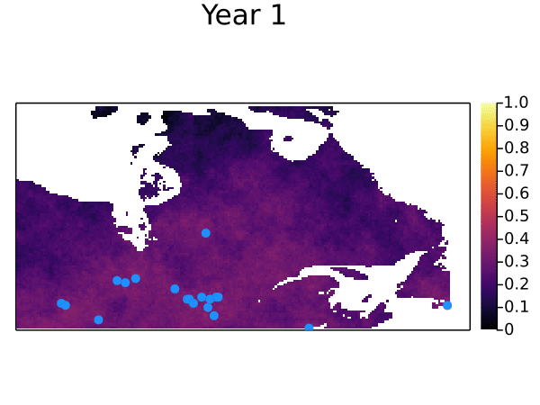

```julia
anim = @animate for (t,s) in enumerate(seq)
    longs, lats = occurrence(s, qcmask, 30; nichemean=0.5, nichewidth=0.05)
    heatmap(s, dpi=150, title = "Year $t", frame=:box, ticks=:none, aspectratio=1, size=(400,300), xlim=(0,220), ylim=(0,110), clim=(0,1))
    scatter!(longs, lats, c=:dodgerblue, msw=0, label="")
end
gif(anim, "result.gif", fps=5)
```